# Risk Factor Analysis

## Outcome Variable

**Outcome Variable:** haz

## Predictor Variables

**Intervention Variable:** earlybf

**Adjustment Set:**

- arm
- sex
- W_mage
- meducyrs
- feducyrs
- hhwealth_quart
- hfoodsec
- W_mhtcm
- W_mwtkg
- W_mbmi
- vagbrth
- W_gagebrth
- W_birthwt
- W_birthlen
- W_nrooms
- W_nchldlt5
- brthmon
- W_parity
- impfloor
- impsan
- safeh20
- delta_W_mage
- delta_meducyrs
- delta_feducyrs
- delta_hhwealth_quart
- delta_hfoodsec
- delta_W_mhtcm
- delta_W_mwtkg
- delta_W_mbmi
- delta_vagbrth
- delta_W_gagebrth
- delta_W_birthwt
- delta_W_birthlen
- delta_W_nrooms
- delta_W_nchldlt5
- delta_brthmon
- delta_W_parity
- delta_impfloor
- delta_impsan
- delta_safeh20

## Stratifying Variables

The analysis was stratified on these variable(s):

- agecat
- studyid
- country

## Data Summary

| agecat | studyid | country | earlybf | n_cell | n |
| --- | --- | --- | --- | --- | --- |
| Birth | EE | PAKISTAN | 1 | 44 | 229 |
| Birth | EE | PAKISTAN | 0 | 185 | 229 |
| Birth | GMS-Nepal | NEPAL | 1 | 180 | 632 |
| Birth | GMS-Nepal | NEPAL | 0 | 452 | 632 |
| Birth | JiVitA-3 | BANGLADESH | 1 | 236 | 22370 |
| Birth | JiVitA-3 | BANGLADESH | 0 | 22134 | 22370 |
| Birth | JiVitA-4 | BANGLADESH | 1 | 1912 | 2823 |
| Birth | JiVitA-4 | BANGLADESH | 0 | 911 | 2823 |
| Birth | MAL-ED | BANGLADESH | 1 | 147 | 230 |
| Birth | MAL-ED | BANGLADESH | 0 | 83 | 230 |
| Birth | MAL-ED | BRAZIL | 1 | 28 | 65 |
| Birth | MAL-ED | BRAZIL | 0 | 37 | 65 |
| Birth | MAL-ED | INDIA | 1 | 32 | 46 |
| Birth | MAL-ED | INDIA | 0 | 14 | 46 |
| Birth | MAL-ED | NEPAL | 1 | 14 | 27 |
| Birth | MAL-ED | NEPAL | 0 | 13 | 27 |
| Birth | MAL-ED | PERU | 1 | 175 | 233 |
| Birth | MAL-ED | PERU | 0 | 58 | 233 |
| Birth | MAL-ED | SOUTH AFRICA | 1 | 69 | 111 |
| Birth | MAL-ED | SOUTH AFRICA | 0 | 42 | 111 |
| Birth | MAL-ED | TANZANIA, UNITED REPUBLIC OF | 1 | 111 | 125 |
| Birth | MAL-ED | TANZANIA, UNITED REPUBLIC OF | 0 | 14 | 125 |
| Birth | NIH-Crypto | BANGLADESH | 1 | 634 | 732 |
| Birth | NIH-Crypto | BANGLADESH | 0 | 98 | 732 |
| Birth | SAS-CompFeed | INDIA | 1 | 86 | 1207 |
| Birth | SAS-CompFeed | INDIA | 0 | 1121 | 1207 |
| Birth | ZVITAMBO | ZIMBABWE | 1 | 6556 | 12354 |
| Birth | ZVITAMBO | ZIMBABWE | 0 | 5798 | 12354 |
| 6 months | EE | PAKISTAN | 1 | 68 | 362 |
| 6 months | EE | PAKISTAN | 0 | 294 | 362 |

[output cut: 52 more lines]

The following strata were considered:

- agecat: 24 months, studyid: EE, country: PAKISTAN
- agecat: 24 months, studyid: GMS-Nepal, country: NEPAL
- agecat: 24 months, studyid: JiVitA-3, country: BANGLADESH
- agecat: 24 months, studyid: JiVitA-4, country: BANGLADESH
- agecat: 24 months, studyid: MAL-ED, country: BANGLADESH
- agecat: 24 months, studyid: MAL-ED, country: BRAZIL
- agecat: 24 months, studyid: MAL-ED, country: INDIA
- agecat: 24 months, studyid: MAL-ED, country: NEPAL
- agecat: 24 months, studyid: MAL-ED, country: PERU
- agecat: 24 months, studyid: MAL-ED, country: SOUTH AFRICA
- agecat: 24 months, studyid: MAL-ED, country: TANZANIA, UNITED REPUBLIC OF
- agecat: 24 months, studyid: NIH-Crypto, country: BANGLADESH
- agecat: 24 months, studyid: ZVITAMBO, country: ZIMBABWE
- agecat: 6 months, studyid: EE, country: PAKISTAN
- agecat: 6 months, studyid: GMS-Nepal, country: NEPAL
- agecat: 6 months, studyid: JiVitA-3, country: BANGLADESH
- agecat: 6 months, studyid: JiVitA-4, country: BANGLADESH
- agecat: 6 months, studyid: MAL-ED, country: BANGLADESH
- agecat: 6 months, studyid: MAL-ED, country: BRAZIL
- agecat: 6 months, studyid: MAL-ED, country: INDIA
- agecat: 6 months, studyid: MAL-ED, country: NEPAL
- agecat: 6 months, studyid: MAL-ED, country: PERU
- agecat: 6 months, studyid: MAL-ED, country: SOUTH AFRICA
- agecat: 6 months, studyid: MAL-ED, country: TANZANIA, UNITED REPUBLIC OF
- agecat: 6 months, studyid: NIH-Crypto, country: BANGLADESH
- agecat: 6 months, studyid: SAS-CompFeed, country: INDIA
- agecat: 6 months, studyid: ZVITAMBO, country: ZIMBABWE
- agecat: Birth, studyid: EE, country: PAKISTAN
- agecat: Birth, studyid: GMS-Nepal, country: NEPAL
- agecat: Birth, studyid: JiVitA-3, country: BANGLADESH
- agecat: Birth, studyid: JiVitA-4, country: BANGLADESH
- agecat: Birth, studyid: MAL-ED, country: BANGLADESH
- agecat: Birth, studyid: MAL-ED, country: BRAZIL
- agecat: Birth, studyid: MAL-ED, country: INDIA
- agecat: Birth, studyid: MAL-ED, country: NEPAL
- agecat: Birth, studyid: MAL-ED, country: PERU
- agecat: Birth, studyid: MAL-ED, country: SOUTH AFRICA
- agecat: Birth, studyid: MAL-ED, country: TANZANIA, UNITED REPUBLIC OF
- agecat: Birth, studyid: NIH-Crypto, country: BANGLADESH
- agecat: Birth, studyid: SAS-CompFeed, country: INDIA
- agecat: Birth, studyid: ZVITAMBO, country: ZIMBABWE

### Dropped Strata

Some strata were dropped due to rare outcomes:

- agecat: 24 months, studyid: JiVitA-3, country: BANGLADESH

## Methods Detail

We’re interested in the causal parameters $E[Y_a]$ for all values of $a \in \mathcal{A}$. These parameters represent the mean outcome if, possibly contrary to fact, we intervened to set all units to have $A=a$. Under the randomization and positivity assumptions, these are identified by the statistical parameters $\psi_a=E_W[E_{Y|A,W}(Y|A=a,W)]$. In addition, we’re interested in the mean of $Y$, $E[Y]$ under no intervention (the observed mean). We will estimate these parameters by using SuperLearner to fit the relevant likelihood factors – $E_{Y|A,W}(Y|A=a,W)$ and $p(A=a|W)$, and then updating our likelihood fit using a joint TMLE.

For unadjusted analyses ($W=\{\}$), initial likelihoods were estimated using Lrnr_glm to estimate the simple $E(Y|A)$ and Lrnr_mean to estimate $p(A)$. For adjusted analyses, a small library containing Lrnr_glmnet, Lrnr_xgboost, and Lrnr_mean was used.

Having estimated these parameters, we will then use the delta method to estimate relative risks and attributable risks relative to a prespecified baseline level of $A$.

# Results Detail

## Results Plots

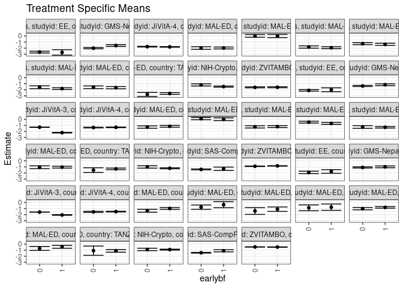

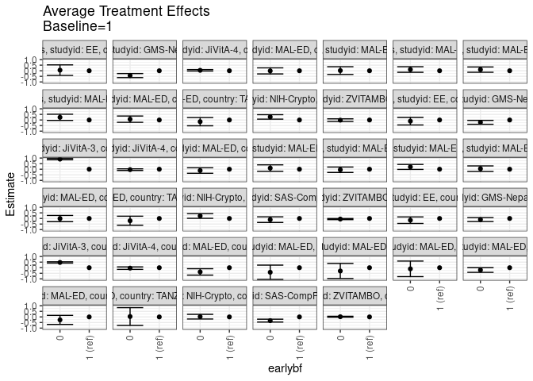

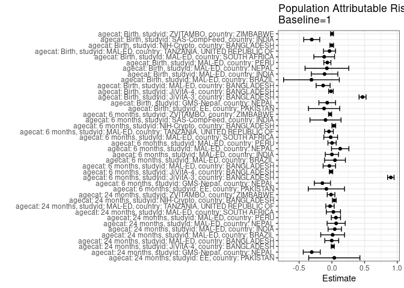

## Results Table

### Parameter: TSM

| agecat | studyid | country | intervention_level | baseline_level | estimate | ci_lower | ci_upper |
| --- | --- | --- | --- | --- | --- | --- | --- |
| Birth | EE | PAKISTAN | 1 | NA | -1.7524138 | -2.0524305 | -1.4523971 |
| Birth | EE | PAKISTAN | 0 | NA | -1.9069296 | -2.1087467 | -1.7051126 |
| Birth | GMS-Nepal | NEPAL | 1 | NA | -0.9870250 | -1.1388113 | -0.8352388 |
| Birth | GMS-Nepal | NEPAL | 0 | NA | -1.0869618 | -1.1853267 | -0.9885969 |
| Birth | JiVitA-3 | BANGLADESH | 1 | NA | -2.0588794 | -2.1127296 | -2.0050292 |
| Birth | JiVitA-3 | BANGLADESH | 0 | NA | -1.5873545 | -1.6069267 | -1.5677824 |
| Birth | JiVitA-4 | BANGLADESH | 1 | NA | -1.5094935 | -1.5670717 | -1.4519152 |
| Birth | JiVitA-4 | BANGLADESH | 0 | NA | -1.5489223 | -1.6424848 | -1.4553598 |
| Birth | MAL-ED | BANGLADESH | 1 | NA | -0.9885001 | -1.1481522 | -0.8288480 |
| Birth | MAL-ED | BANGLADESH | 0 | NA | -1.3660117 | -1.6035340 | -1.1284895 |
| Birth | MAL-ED | BRAZIL | 1 | NA | -0.3643259 | -0.8642873 | 0.1356355 |
| Birth | MAL-ED | BRAZIL | 0 | NA | -0.7739240 | -1.1314218 | -0.4164261 |
| Birth | MAL-ED | INDIA | 1 | NA | -1.1107705 | -1.4775987 | -0.7439423 |
| Birth | MAL-ED | INDIA | 0 | NA | -1.4056307 | -1.9693850 | -0.8418765 |
| Birth | MAL-ED | NEPAL | 1 | NA | -0.7776479 | -1.2989445 | -0.2563513 |
| Birth | MAL-ED | NEPAL | 0 | NA | -0.8810310 | -1.3634219 | -0.3986401 |
| Birth | MAL-ED | PERU | 1 | NA | -0.8139462 | -0.9423985 | -0.6854938 |
| Birth | MAL-ED | PERU | 0 | NA | -1.0222432 | -1.2139582 | -0.8305282 |
| Birth | MAL-ED | SOUTH AFRICA | 1 | NA | -0.4536706 | -0.6881157 | -0.2192254 |
| Birth | MAL-ED | SOUTH AFRICA | 0 | NA | -0.7187867 | -1.0468104 | -0.3907630 |
| Birth | MAL-ED | TANZANIA, UNITED REPUBLIC OF | 1 | NA | -1.1197378 | -1.3362734 | -0.9032023 |
| Birth | MAL-ED | TANZANIA, UNITED REPUBLIC OF | 0 | NA | -1.0849747 | -1.8486549 | -0.3212945 |
| Birth | NIH-Crypto | BANGLADESH | 1 | NA | -0.9075445 | -0.9825218 | -0.8325673 |
| Birth | NIH-Crypto | BANGLADESH | 0 | NA | -0.8843921 | -1.0839800 | -0.6848041 |
| Birth | SAS-CompFeed | INDIA | 1 | NA | -1.0994066 | -1.2772210 | -0.9215922 |
| Birth | SAS-CompFeed | INDIA | 0 | NA | -1.4308867 | -1.4933116 | -1.3684618 |
| Birth | ZVITAMBO | ZIMBABWE | 1 | NA | -0.4922462 | -0.5227669 | -0.4617255 |
| Birth | ZVITAMBO | ZIMBABWE | 0 | NA | -0.4758523 | -0.5072392 | -0.4444654 |
| 6 months | EE | PAKISTAN | 1 | NA | -2.0003146 | -2.3166706 | -1.6839586 |
| 6 months | EE | PAKISTAN | 0 | NA | -2.1041375 | -2.2334069 | -1.9748681 |
| 6 months | GMS-Nepal | NEPAL | 1 | NA | -1.1726803 | -1.3195246 | -1.0258361 |
| 6 months | GMS-Nepal | NEPAL | 0 | NA | -1.3818273 | -1.4785035 | -1.2851512 |
| 6 months | JiVitA-3 | BANGLADESH | 1 | NA | -2.2145730 | -2.2601404 | -2.1690055 |
| 6 months | JiVitA-3 | BANGLADESH | 0 | NA | -1.3111158 | -1.3347273 | -1.2875043 |
| 6 months | JiVitA-4 | BANGLADESH | 1 | NA | -1.3320986 | -1.3782615 | -1.2859357 |
| 6 months | JiVitA-4 | BANGLADESH | 0 | NA | -1.3683416 | -1.4266775 | -1.3100057 |
| 6 months | MAL-ED | BANGLADESH | 1 | NA | -1.1673163 | -1.3171986 | -1.0174340 |
| 6 months | MAL-ED | BANGLADESH | 0 | NA | -1.2842938 | -1.4780361 | -1.0905515 |
| 6 months | MAL-ED | BRAZIL | 1 | NA | 0.0001441 | -0.2220210 | 0.2223092 |
| 6 months | MAL-ED | BRAZIL | 0 | NA | 0.1019584 | -0.0857470 | 0.2896639 |
| 6 months | MAL-ED | INDIA | 1 | NA | -1.2121001 | -1.3662915 | -1.0579086 |
| 6 months | MAL-ED | INDIA | 0 | NA | -1.2594147 | -1.4453632 | -1.0734661 |
| 6 months | MAL-ED | NEPAL | 1 | NA | -0.6892656 | -0.8535317 | -0.5249995 |
| 6 months | MAL-ED | NEPAL | 0 | NA | -0.4826428 | -0.6342115 | -0.3310741 |
| 6 months | MAL-ED | PERU | 1 | NA | -1.3266850 | -1.4539994 | -1.1993706 |
| 6 months | MAL-ED | PERU | 0 | NA | -1.2794368 | -1.4910582 | -1.0678154 |
| 6 months | MAL-ED | SOUTH AFRICA | 1 | NA | -1.0420514 | -1.1963052 | -0.8877975 |
| 6 months | MAL-ED | SOUTH AFRICA | 0 | NA | -1.0507905 | -1.2809363 | -0.8206447 |
| 6 months | MAL-ED | TANZANIA, UNITED REPUBLIC OF | 1 | NA | -1.3244835 | -1.4530030 | -1.1959640 |
| 6 months | MAL-ED | TANZANIA, UNITED REPUBLIC OF | 0 | NA | -1.5282614 | -1.9125777 | -1.1439450 |
| 6 months | NIH-Crypto | BANGLADESH | 1 | NA | -1.2284180 | -1.3049355 | -1.1519006 |
| 6 months | NIH-Crypto | BANGLADESH | 0 | NA | -1.0035343 | -1.2002488 | -0.8068198 |
| 6 months | SAS-CompFeed | INDIA | 1 | NA | -1.3046030 | -1.5804232 | -1.0287828 |
| 6 months | SAS-CompFeed | INDIA | 0 | NA | -1.4110959 | -1.4864420 | -1.3357497 |
| 6 months | ZVITAMBO | ZIMBABWE | 1 | NA | -0.8354682 | -0.8709683 | -0.7999680 |
| 6 months | ZVITAMBO | ZIMBABWE | 0 | NA | -0.8903708 | -0.9291195 | -0.8516221 |
| 24 months | EE | PAKISTAN | 1 | NA | -2.7053123 | -3.1533848 | -2.2572397 |
| 24 months | EE | PAKISTAN | 0 | NA | -2.6505160 | -2.7985524 | -2.5024795 |
| 24 months | GMS-Nepal | NEPAL | 1 | NA | -1.5719765 | -1.7198043 | -1.4241487 |
| 24 months | GMS-Nepal | NEPAL | 0 | NA | -2.0029013 | -2.1123282 | -1.8934744 |
| 24 months | JiVitA-4 | BANGLADESH | 1 | NA | -1.7944995 | -1.8391425 | -1.7498564 |
| 24 months | JiVitA-4 | BANGLADESH | 0 | NA | -1.7548979 | -1.8082646 | -1.7015312 |
| 24 months | MAL-ED | BANGLADESH | 1 | NA | -1.9719622 | -2.1296654 | -1.8142589 |
| 24 months | MAL-ED | BANGLADESH | 0 | NA | -1.9835835 | -2.2031803 | -1.7639867 |
| 24 months | MAL-ED | BRAZIL | 1 | NA | -0.0059366 | -0.2635329 | 0.2516596 |
| 24 months | MAL-ED | BRAZIL | 0 | NA | 0.0112604 | -0.2163996 | 0.2389205 |
| 24 months | MAL-ED | INDIA | 1 | NA | -1.9306026 | -2.0952759 | -1.7659292 |
| 24 months | MAL-ED | INDIA | 0 | NA | -1.8175012 | -2.0059086 | -1.6290937 |
| 24 months | MAL-ED | NEPAL | 1 | NA | -1.3733572 | -1.5468896 | -1.1998249 |
| 24 months | MAL-ED | NEPAL | 0 | NA | -1.2700551 | -1.4329343 | -1.1071759 |
| 24 months | MAL-ED | PERU | 1 | NA | -1.8144174 | -1.9554617 | -1.6733731 |
| 24 months | MAL-ED | PERU | 0 | NA | -1.5740298 | -1.8107663 | -1.3372933 |
| 24 months | MAL-ED | SOUTH AFRICA | 1 | NA | -1.6599657 | -1.8342979 | -1.4856336 |
| 24 months | MAL-ED | SOUTH AFRICA | 0 | NA | -1.5868140 | -1.8077208 | -1.3659073 |
| 24 months | MAL-ED | TANZANIA, UNITED REPUBLIC OF | 1 | NA | -2.6171271 | -2.7622419 | -2.4720123 |
| 24 months | MAL-ED | TANZANIA, UNITED REPUBLIC OF | 0 | NA | -2.7659148 | -3.1042885 | -2.4275410 |
| 24 months | NIH-Crypto | BANGLADESH | 1 | NA | -1.4790304 | -1.5713807 | -1.3866801 |
| 24 months | NIH-Crypto | BANGLADESH | 0 | NA | -1.2033244 | -1.3806231 | -1.0260258 |
| 24 months | ZVITAMBO | ZIMBABWE | 1 | NA | -1.5881842 | -1.6736054 | -1.5027629 |
| 24 months | ZVITAMBO | ZIMBABWE | 0 | NA | -1.6033971 | -1.6871809 | -1.5196134 |

### Parameter: E(Y)

| agecat | studyid | country | intervention_level | baseline_level | estimate | ci_lower | ci_upper |
| --- | --- | --- | --- | --- | --- | --- | --- |
| Birth | EE | PAKISTAN | NA | NA | -1.8713537 | -2.0647180 | -1.6779894 |
| Birth | GMS-Nepal | NEPAL | NA | NA | -1.0578481 | -1.1411010 | -0.9745953 |
| Birth | JiVitA-3 | BANGLADESH | NA | NA | -1.5896710 | -1.6089649 | -1.5703770 |
| Birth | JiVitA-4 | BANGLADESH | NA | NA | -1.5232908 | -1.5723277 | -1.4742539 |
| Birth | MAL-ED | BANGLADESH | NA | NA | -1.1218261 | -1.2566576 | -0.9869945 |
| Birth | MAL-ED | BRAZIL | NA | NA | -0.6760000 | -0.9521457 | -0.3998543 |
| Birth | MAL-ED | INDIA | NA | NA | -1.2221739 | -1.5203945 | -0.9239534 |
| Birth | MAL-ED | NEPAL | NA | NA | -0.8533333 | -1.2104864 | -0.4961803 |
| Birth | MAL-ED | PERU | NA | NA | -0.8827897 | -1.0001058 | -0.7654736 |
| Birth | MAL-ED | SOUTH AFRICA | NA | NA | -0.5709009 | -0.7569265 | -0.3848753 |
| Birth | MAL-ED | TANZANIA, UNITED REPUBLIC OF | NA | NA | -1.1556000 | -1.3655361 | -0.9456639 |
| Birth | NIH-Crypto | BANGLADESH | NA | NA | -0.9094945 | -0.9809370 | -0.8380521 |
| Birth | SAS-CompFeed | INDIA | NA | NA | -1.4072245 | -1.4817853 | -1.3326638 |
| Birth | ZVITAMBO | ZIMBABWE | NA | NA | -0.4895257 | -0.5113672 | -0.4676841 |
| 6 months | EE | PAKISTAN | NA | NA | -2.0838858 | -2.2054394 | -1.9623322 |
| 6 months | GMS-Nepal | NEPAL | NA | NA | -1.3175310 | -1.3993963 | -1.2356656 |
| 6 months | JiVitA-3 | BANGLADESH | NA | NA | -1.3130932 | -1.3362359 | -1.2899505 |
| 6 months | JiVitA-4 | BANGLADESH | NA | NA | -1.3447940 | -1.3820261 | -1.3075620 |
| 6 months | MAL-ED | BANGLADESH | NA | NA | -1.2056389 | -1.3233420 | -1.0879358 |
| 6 months | MAL-ED | BRAZIL | NA | NA | 0.0475758 | -0.0963508 | 0.1915023 |
| 6 months | MAL-ED | INDIA | NA | NA | -1.2115254 | -1.3298727 | -1.0931782 |
| 6 months | MAL-ED | NEPAL | NA | NA | -0.5615819 | -0.6741832 | -0.4489807 |
| 6 months | MAL-ED | PERU | NA | NA | -1.3236661 | -1.4316775 | -1.2156546 |
| 6 months | MAL-ED | SOUTH AFRICA | NA | NA | -1.0598800 | -1.1885688 | -0.9311912 |
| 6 months | MAL-ED | TANZANIA, UNITED REPUBLIC OF | NA | NA | -1.3687449 | -1.4907629 | -1.2467270 |
| 6 months | NIH-Crypto | BANGLADESH | NA | NA | -1.1986783 | -1.2700937 | -1.1272630 |
| 6 months | SAS-CompFeed | INDIA | NA | NA | -1.4018563 | -1.4810585 | -1.3226541 |
| 6 months | ZVITAMBO | ZIMBABWE | NA | NA | -0.8625370 | -0.8897591 | -0.8353150 |
| 24 months | EE | PAKISTAN | NA | NA | -2.6678252 | -2.8138884 | -2.5217620 |
| 24 months | GMS-Nepal | NEPAL | NA | NA | -1.8793783 | -1.9705101 | -1.7882464 |
| 24 months | JiVitA-4 | BANGLADESH | NA | NA | -1.7807218 | -1.8162478 | -1.7451958 |
| 24 months | MAL-ED | BANGLADESH | NA | NA | -1.9735782 | -2.1004502 | -1.8467062 |
| 24 months | MAL-ED | BRAZIL | NA | NA | 0.0061144 | -0.1625850 | 0.1748138 |
| 24 months | MAL-ED | INDIA | NA | NA | -1.8861894 | -2.0110006 | -1.7613783 |
| 24 months | MAL-ED | NEPAL | NA | NA | -1.3075877 | -1.4270718 | -1.1881037 |
| 24 months | MAL-ED | PERU | NA | NA | -1.7524710 | -1.8736426 | -1.6312994 |
| 24 months | MAL-ED | SOUTH AFRICA | NA | NA | -1.6365071 | -1.7722110 | -1.5008032 |
| 24 months | MAL-ED | TANZANIA, UNITED REPUBLIC OF | NA | NA | -2.6455607 | -2.7807256 | -2.5103959 |
| 24 months | NIH-Crypto | BANGLADESH | NA | NA | -1.4412646 | -1.5249156 | -1.3576135 |
| 24 months | ZVITAMBO | ZIMBABWE | NA | NA | -1.6006366 | -1.6621572 | -1.5391159 |

### Parameter: ATE

| agecat | studyid | country | intervention_level | baseline_level | estimate | ci_lower | ci_upper |
| --- | --- | --- | --- | --- | --- | --- | --- |
| Birth | EE | PAKISTAN | 1 | 1 | 0.0000000 | 0.0000000 | 0.0000000 |
| Birth | EE | PAKISTAN | 0 | 1 | -0.1545158 | -0.4461301 | 0.1370985 |
| Birth | GMS-Nepal | NEPAL | 1 | 1 | 0.0000000 | 0.0000000 | 0.0000000 |
| Birth | GMS-Nepal | NEPAL | 0 | 1 | -0.0999368 | -0.2756015 | 0.0757280 |
| Birth | JiVitA-3 | BANGLADESH | 1 | 1 | 0.0000000 | 0.0000000 | 0.0000000 |
| Birth | JiVitA-3 | BANGLADESH | 0 | 1 | 0.4715249 | 0.4164551 | 0.5265947 |
| Birth | JiVitA-4 | BANGLADESH | 1 | 1 | 0.0000000 | 0.0000000 | 0.0000000 |
| Birth | JiVitA-4 | BANGLADESH | 0 | 1 | -0.0394288 | -0.1495584 | 0.0707007 |
| Birth | MAL-ED | BANGLADESH | 1 | 1 | 0.0000000 | 0.0000000 | 0.0000000 |
| Birth | MAL-ED | BANGLADESH | 0 | 1 | -0.3775116 | -0.6641117 | -0.0909115 |
| Birth | MAL-ED | BRAZIL | 1 | 1 | 0.0000000 | 0.0000000 | 0.0000000 |
| Birth | MAL-ED | BRAZIL | 0 | 1 | -0.4095981 | -1.0500136 | 0.2308174 |
| Birth | MAL-ED | INDIA | 1 | 1 | 0.0000000 | 0.0000000 | 0.0000000 |
| Birth | MAL-ED | INDIA | 0 | 1 | -0.2948603 | -0.9723285 | 0.3826080 |
| Birth | MAL-ED | NEPAL | 1 | 1 | 0.0000000 | 0.0000000 | 0.0000000 |
| Birth | MAL-ED | NEPAL | 0 | 1 | -0.1033831 | -0.7985012 | 0.5917350 |
| Birth | MAL-ED | PERU | 1 | 1 | 0.0000000 | 0.0000000 | 0.0000000 |
| Birth | MAL-ED | PERU | 0 | 1 | -0.2082970 | -0.4153574 | -0.0012367 |
| Birth | MAL-ED | SOUTH AFRICA | 1 | 1 | 0.0000000 | 0.0000000 | 0.0000000 |
| Birth | MAL-ED | SOUTH AFRICA | 0 | 1 | -0.2651161 | -0.6714217 | 0.1411894 |
| Birth | MAL-ED | TANZANIA, UNITED REPUBLIC OF | 1 | 1 | 0.0000000 | 0.0000000 | 0.0000000 |
| Birth | MAL-ED | TANZANIA, UNITED REPUBLIC OF | 0 | 1 | 0.0347631 | -0.7618589 | 0.8313852 |
| Birth | NIH-Crypto | BANGLADESH | 1 | 1 | 0.0000000 | 0.0000000 | 0.0000000 |
| Birth | NIH-Crypto | BANGLADESH | 0 | 1 | 0.0231525 | -0.1864963 | 0.2328012 |
| Birth | SAS-CompFeed | INDIA | 1 | 1 | 0.0000000 | 0.0000000 | 0.0000000 |
| Birth | SAS-CompFeed | INDIA | 0 | 1 | -0.3314801 | -0.4594813 | -0.2034788 |
| Birth | ZVITAMBO | ZIMBABWE | 1 | 1 | 0.0000000 | 0.0000000 | 0.0000000 |
| Birth | ZVITAMBO | ZIMBABWE | 0 | 1 | 0.0163939 | -0.0260029 | 0.0587907 |
| 6 months | EE | PAKISTAN | 1 | 1 | 0.0000000 | 0.0000000 | 0.0000000 |
| 6 months | EE | PAKISTAN | 0 | 1 | -0.1038229 | -0.4431752 | 0.2355295 |
| 6 months | GMS-Nepal | NEPAL | 1 | 1 | 0.0000000 | 0.0000000 | 0.0000000 |
| 6 months | GMS-Nepal | NEPAL | 0 | 1 | -0.2091470 | -0.3831542 | -0.0351398 |
| 6 months | JiVitA-3 | BANGLADESH | 1 | 1 | 0.0000000 | 0.0000000 | 0.0000000 |
| 6 months | JiVitA-3 | BANGLADESH | 0 | 1 | 0.9034572 | 0.8527042 | 0.9542102 |
| 6 months | JiVitA-4 | BANGLADESH | 1 | 1 | 0.0000000 | 0.0000000 | 0.0000000 |
| 6 months | JiVitA-4 | BANGLADESH | 0 | 1 | -0.0362430 | -0.1083745 | 0.0358886 |
| 6 months | MAL-ED | BANGLADESH | 1 | 1 | 0.0000000 | 0.0000000 | 0.0000000 |
| 6 months | MAL-ED | BANGLADESH | 0 | 1 | -0.1169775 | -0.3632223 | 0.1292673 |
| 6 months | MAL-ED | BRAZIL | 1 | 1 | 0.0000000 | 0.0000000 | 0.0000000 |
| 6 months | MAL-ED | BRAZIL | 0 | 1 | 0.1018143 | -0.1877349 | 0.3913635 |
| 6 months | MAL-ED | INDIA | 1 | 1 | 0.0000000 | 0.0000000 | 0.0000000 |
| 6 months | MAL-ED | INDIA | 0 | 1 | -0.0473146 | -0.2897468 | 0.1951176 |
| 6 months | MAL-ED | NEPAL | 1 | 1 | 0.0000000 | 0.0000000 | 0.0000000 |
| 6 months | MAL-ED | NEPAL | 0 | 1 | 0.2066228 | -0.0164567 | 0.4297024 |
| 6 months | MAL-ED | PERU | 1 | 1 | 0.0000000 | 0.0000000 | 0.0000000 |
| 6 months | MAL-ED | PERU | 0 | 1 | 0.0472483 | -0.2015673 | 0.2960638 |
| 6 months | MAL-ED | SOUTH AFRICA | 1 | 1 | 0.0000000 | 0.0000000 | 0.0000000 |
| 6 months | MAL-ED | SOUTH AFRICA | 0 | 1 | -0.0087391 | -0.2872489 | 0.2697707 |
| 6 months | MAL-ED | TANZANIA, UNITED REPUBLIC OF | 1 | 1 | 0.0000000 | 0.0000000 | 0.0000000 |
| 6 months | MAL-ED | TANZANIA, UNITED REPUBLIC OF | 0 | 1 | -0.2037779 | -0.6096683 | 0.2021125 |
| 6 months | NIH-Crypto | BANGLADESH | 1 | 1 | 0.0000000 | 0.0000000 | 0.0000000 |
| 6 months | NIH-Crypto | BANGLADESH | 0 | 1 | 0.2248837 | 0.0137695 | 0.4359979 |
| 6 months | SAS-CompFeed | INDIA | 1 | 1 | 0.0000000 | 0.0000000 | 0.0000000 |
| 6 months | SAS-CompFeed | INDIA | 0 | 1 | -0.1064929 | -0.3580352 | 0.1450495 |
| 6 months | ZVITAMBO | ZIMBABWE | 1 | 1 | 0.0000000 | 0.0000000 | 0.0000000 |
| 6 months | ZVITAMBO | ZIMBABWE | 0 | 1 | -0.0549026 | -0.1045570 | -0.0052483 |
| 24 months | EE | PAKISTAN | 1 | 1 | 0.0000000 | 0.0000000 | 0.0000000 |
| 24 months | EE | PAKISTAN | 0 | 1 | 0.0547963 | -0.4179054 | 0.5274980 |
| 24 months | GMS-Nepal | NEPAL | 1 | 1 | 0.0000000 | 0.0000000 | 0.0000000 |
| 24 months | GMS-Nepal | NEPAL | 0 | 1 | -0.4309247 | -0.6127346 | -0.2491149 |
| 24 months | JiVitA-4 | BANGLADESH | 1 | 1 | 0.0000000 | 0.0000000 | 0.0000000 |
| 24 months | JiVitA-4 | BANGLADESH | 0 | 1 | 0.0396016 | -0.0260848 | 0.1052879 |
| 24 months | MAL-ED | BANGLADESH | 1 | 1 | 0.0000000 | 0.0000000 | 0.0000000 |
| 24 months | MAL-ED | BANGLADESH | 0 | 1 | -0.0116214 | -0.2827800 | 0.2595373 |
| 24 months | MAL-ED | BRAZIL | 1 | 1 | 0.0000000 | 0.0000000 | 0.0000000 |
| 24 months | MAL-ED | BRAZIL | 0 | 1 | 0.0171971 | -0.3286887 | 0.3630829 |
| 24 months | MAL-ED | INDIA | 1 | 1 | 0.0000000 | 0.0000000 | 0.0000000 |
| 24 months | MAL-ED | INDIA | 0 | 1 | 0.1131014 | -0.1358120 | 0.3620148 |
| 24 months | MAL-ED | NEPAL | 1 | 1 | 0.0000000 | 0.0000000 | 0.0000000 |
| 24 months | MAL-ED | NEPAL | 0 | 1 | 0.1033021 | -0.1340016 | 0.3406058 |
| 24 months | MAL-ED | PERU | 1 | 1 | 0.0000000 | 0.0000000 | 0.0000000 |
| 24 months | MAL-ED | PERU | 0 | 1 | 0.2403876 | -0.0374552 | 0.5182304 |
| 24 months | MAL-ED | SOUTH AFRICA | 1 | 1 | 0.0000000 | 0.0000000 | 0.0000000 |
| 24 months | MAL-ED | SOUTH AFRICA | 0 | 1 | 0.0731517 | -0.2089961 | 0.3552995 |
| 24 months | MAL-ED | TANZANIA, UNITED REPUBLIC OF | 1 | 1 | 0.0000000 | 0.0000000 | 0.0000000 |
| 24 months | MAL-ED | TANZANIA, UNITED REPUBLIC OF | 0 | 1 | -0.1487877 | -0.5175917 | 0.2200163 |
| 24 months | NIH-Crypto | BANGLADESH | 1 | 1 | 0.0000000 | 0.0000000 | 0.0000000 |
| 24 months | NIH-Crypto | BANGLADESH | 0 | 1 | 0.2757060 | 0.0758249 | 0.4755870 |
| 24 months | ZVITAMBO | ZIMBABWE | 1 | 1 | 0.0000000 | 0.0000000 | 0.0000000 |
| 24 months | ZVITAMBO | ZIMBABWE | 0 | 1 | -0.0152130 | -0.1325970 | 0.1021710 |

### Parameter: PAR

| agecat | studyid | country | intervention_level | baseline_level | estimate | ci_lower | ci_upper |
| --- | --- | --- | --- | --- | --- | --- | --- |
| Birth | EE | PAKISTAN | 1 | NA | -0.1189399 | -0.3578533 | 0.1199735 |
| Birth | GMS-Nepal | NEPAL | 1 | NA | -0.0708231 | -0.1984295 | 0.0567834 |
| Birth | JiVitA-3 | BANGLADESH | 1 | NA | 0.4692084 | 0.4158356 | 0.5225813 |
| Birth | JiVitA-4 | BANGLADESH | 1 | NA | -0.0137974 | -0.0490976 | 0.0215029 |
| Birth | MAL-ED | BANGLADESH | 1 | NA | -0.1333260 | -0.2400729 | -0.0265791 |
| Birth | MAL-ED | BRAZIL | 1 | NA | -0.3116741 | -0.7376382 | 0.1142900 |
| Birth | MAL-ED | INDIA | 1 | NA | -0.1114034 | -0.3135679 | 0.0907611 |
| Birth | MAL-ED | NEPAL | 1 | NA | -0.0756854 | -0.4095972 | 0.2582263 |
| Birth | MAL-ED | PERU | 1 | NA | -0.0688435 | -0.1226385 | -0.0150486 |
| Birth | MAL-ED | SOUTH AFRICA | 1 | NA | -0.1172303 | -0.2758176 | 0.0413570 |
| Birth | MAL-ED | TANZANIA, UNITED REPUBLIC OF | 1 | NA | -0.0358622 | -0.1277024 | 0.0559781 |
| Birth | NIH-Crypto | BANGLADESH | 1 | NA | -0.0019500 | -0.0299282 | 0.0260282 |
| Birth | SAS-CompFeed | INDIA | 1 | NA | -0.3078179 | -0.4303157 | -0.1853201 |
| Birth | ZVITAMBO | ZIMBABWE | 1 | NA | 0.0027205 | -0.0192264 | 0.0246675 |
| 6 months | EE | PAKISTAN | 1 | NA | -0.0835712 | -0.3604216 | 0.1932792 |
| 6 months | GMS-Nepal | NEPAL | 1 | NA | -0.1448507 | -0.2680268 | -0.0216745 |
| 6 months | JiVitA-3 | BANGLADESH | 1 | NA | 0.9014798 | 0.8519397 | 0.9510198 |
| 6 months | JiVitA-4 | BANGLADESH | 1 | NA | -0.0126954 | -0.0391029 | 0.0137120 |
| 6 months | MAL-ED | BANGLADESH | 1 | NA | -0.0383226 | -0.1334923 | 0.0568471 |
| 6 months | MAL-ED | BRAZIL | 1 | NA | 0.0474316 | -0.1121251 | 0.2069884 |
| 6 months | MAL-ED | INDIA | 1 | NA | 0.0005747 | -0.1004393 | 0.1015887 |
| 6 months | MAL-ED | NEPAL | 1 | NA | 0.1276837 | -0.0050466 | 0.2604140 |
| 6 months | MAL-ED | PERU | 1 | NA | 0.0030190 | -0.0602794 | 0.0663173 |
| 6 months | MAL-ED | SOUTH AFRICA | 1 | NA | -0.0178286 | -0.1228686 | 0.0872114 |
| 6 months | MAL-ED | TANZANIA, UNITED REPUBLIC OF | 1 | NA | -0.0442615 | -0.1107307 | 0.0222078 |
| 6 months | NIH-Crypto | BANGLADESH | 1 | NA | 0.0297397 | 0.0010826 | 0.0583968 |
| 6 months | SAS-CompFeed | INDIA | 1 | NA | -0.0972533 | -0.3350924 | 0.1405858 |
| 6 months | ZVITAMBO | ZIMBABWE | 1 | NA | -0.0270688 | -0.0503234 | -0.0038143 |
| 24 months | EE | PAKISTAN | 1 | NA | 0.0374871 | -0.3538084 | 0.4287825 |
| 24 months | GMS-Nepal | NEPAL | 1 | NA | -0.3074018 | -0.4372778 | -0.1775257 |
| 24 months | JiVitA-4 | BANGLADESH | 1 | NA | 0.0137777 | -0.0098331 | 0.0373884 |
| 24 months | MAL-ED | BANGLADESH | 1 | NA | -0.0016160 | -0.1074681 | 0.1042360 |
| 24 months | MAL-ED | BRAZIL | 1 | NA | 0.0120510 | -0.1701273 | 0.1942293 |
| 24 months | MAL-ED | INDIA | 1 | NA | 0.0444131 | -0.0580637 | 0.1468899 |
| 24 months | MAL-ED | NEPAL | 1 | NA | 0.0657695 | -0.0726081 | 0.2041471 |
| 24 months | MAL-ED | PERU | 1 | NA | 0.0619464 | -0.0087338 | 0.1326267 |
| 24 months | MAL-ED | SOUTH AFRICA | 1 | NA | 0.0234586 | -0.0850432 | 0.1319605 |
| 24 months | MAL-ED | TANZANIA, UNITED REPUBLIC OF | 1 | NA | -0.0284337 | -0.0926107 | 0.0357434 |
| 24 months | NIH-Crypto | BANGLADESH | 1 | NA | 0.0377658 | 0.0091486 | 0.0663830 |
| 24 months | ZVITAMBO | ZIMBABWE | 1 | NA | -0.0124524 | -0.0707476 | 0.0458428 |